# PMM3: Linear Regression for Symmetric Platykurtic Errors

Serhii Zabolotnii

2026-09-19

## The Problem: When OLS and PMM2 Are Not Enough

Ordinary Least Squares (OLS) is optimal for Gaussian errors. **PMM2** improves upon OLS when errors are **asymmetric** (skewed). But what about errors that are **symmetric yet non-Gaussian**?

Many real-world processes produce errors with **lighter tails** than the normal distribution (**platykurtic** errors, $\gamma_4 < 0$). In these cases:

- OLS is suboptimal — it does not exploit the known platykurtic structure
- PMM2 provides no improvement — it relies on the third moment (skewness), which is zero for symmetric distributions

### Where Platykurtic Errors Arise

- **Bounded measurement errors**: sensors with a fixed operating range
- **Rounding errors**: uniformly distributed within the rounding interval
- **Truncated normal processes**: censored at fixed bounds
- **Beta-distributed disturbances**: bounded economic indicators, proportions
- **Quality control**: manufacturing tolerances with hard limits

## The Solution: PMM3 (Polynomial Maximization Method, S=3)

**PMM3** constructs a cubic stochastic polynomial using the fourth and sixth central moments. The key theoretical quantities:

- **Excess kurtosis**: $\gamma_4 = m_4 / m_2^2 - 3$
- **Sixth-order coefficient**: $\gamma_6 = m_6 / m_2^3 - 15 m_4/m_2^2 + 30$
- **Efficiency factor**: $g_3 = 1 - \gamma_4^2 / (6 + 9\gamma_4 + \gamma_6)$

The factor $g_3$ is the ratio $\text{Var}(\hat{\beta}_{\text{PMM3}}) / \text{Var}(\hat{\beta}_{\text{OLS}})$. When $g_3 < 1$, PMM3 achieves lower variance than OLS.

### The Newton-Raphson Algorithm

PMM3 iteratively refines OLS estimates using the score equation:

with Jacobian $J = X^\top \text{diag}(3\varepsilon^2 - \kappa) X$. The solver includes step-size limiting and a divergence guard for numerical stability.

**Reference:** Based on the theoretical framework of the Polynomial Maximization Method (Zabolotnii et al., 2018).

## Getting Started

```r
library(EstemPMM)
set.seed(42)
```

## Example 1: Simple Regression with Uniform Errors

Uniform errors are the canonical platykurtic case: $\gamma_4 \approx -1.2$, symmetric, bounded.

### Data Generation

```r
n <- 300

# Generate predictor
x <- rnorm(n, mean = 5, sd = 2)

# True parameters
beta_0 <- 10
beta_1 <- 2.5

# Generate uniform errors (platykurtic, gamma4 ≈ -1.2)
errors <- runif(n, -sqrt(3), sqrt(3))  # variance = 1

# Response variable
y <- beta_0 + beta_1 * x + errors
dat <- data.frame(y = y, x = x)
```

### Visualize Error Distribution

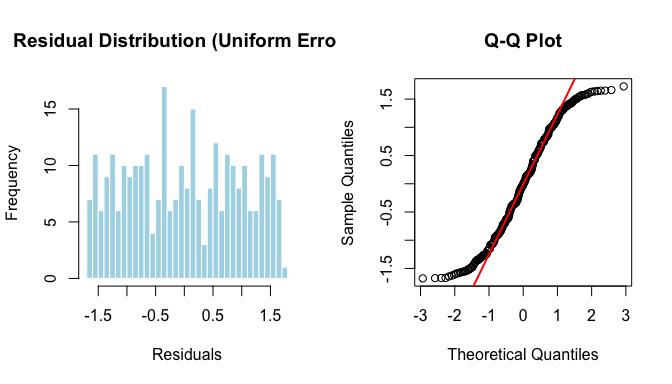

```r
fit_ols_temp <- lm(y ~ x, data = dat)
res_ols <- residuals(fit_ols_temp)

par(mfrow = c(1, 2))
hist(res_ols, breaks = 30, main = "Residual Distribution (Uniform Errors)",
     xlab = "Residuals", col = "lightblue", border = "white")
qqnorm(res_ols, main = "Q-Q Plot")
qqline(res_ols, col = "red", lwd = 2)
```

```r
par(mfrow = c(1, 1))

cat("Skewness (gamma3):", round(pmm_skewness(res_ols), 3), "\n")
```

```
#> Skewness (gamma3): 0.026
```

```r
cat("Excess kurtosis (gamma4):", round(pmm_kurtosis(res_ols), 3), "\n")
```

```
#> Excess kurtosis (gamma4): -1.183
```

The Q-Q plot shows **lighter tails** than normal (S-shaped curve with compressed ends). The skewness is near zero but kurtosis is clearly negative.

### Automatic Method Selection

```r
recommendation <- pmm_dispatch(res_ols)
```

```
#> PMM method dispatch
#>   n = 300 | gamma3 = +0.026 | gamma4 = -1.183
#>   g2(PMM2) = 0.9992 | g3(PMM3) = 0.3083
#>   Selected: PMM3 (expected variance reduction: 69.2%)
#>   Reason: |gamma3| = 0.026 < 0.3 (symmetric) and gamma4 = -1.183 < -0.7 (platykurtic). PMM3 expected to reduce variance by 69.2%.
```

### Fit PMM3

```r
fit_pmm3 <- lm_pmm3(y ~ x, data = dat)
fit_ols  <- lm(y ~ x, data = dat)

# Display PMM3 summary
summary(fit_pmm3)
```

```
#> PMM3 estimation results (S = 3, symmetric errors)
#> Call:
#> lm_pmm3(formula = y ~ x, data = dat)
#>
#> Coefficients:
#> (Intercept)           x
#>    9.916678    2.518456
#>
#> Central moments of initial residuals:
#>   m2 = 0.9555941
#>   m4 = 1.658808
#>   m6 = 3.424153
#>
#> Theoretical characteristics of PMM3 (S = 3):
#>   gamma4 = -1.183442
#>   gamma6 = 6.675667
#>   g3     = 0.3082707  (expected ratio Var[PMM3]/Var[OLS])
#>   kappa  = 1.231908
#>
#> Algorithm information:
#>   Convergence status: TRUE
#>   Iterations: 3
```

### Compare with OLS

```r
comparison <- data.frame(
  Parameter = c("Intercept", "Slope"),
  True  = c(beta_0, beta_1),
  OLS   = coef(fit_ols),
  PMM3  = coef(fit_pmm3),
  Diff  = coef(fit_pmm3) - coef(fit_ols)
)
print(comparison, row.names = FALSE)
```

```
#>  Parameter True      OLS     PMM3        Diff
#>  Intercept 10.0 9.804314 9.916678  0.11236314
#>      Slope  2.5 2.537942 2.518456 -0.01948666
```

```r
cat("\nResidual sum of squares:\n")
```

```
#>
#> Residual sum of squares:
```

```r
cat("  OLS:  ", sum(residuals(fit_ols)^2), "\n")
```

```
#>   OLS:   286.6782
```

```r
cat("  PMM3: ", sum(residuals(fit_pmm3)^2), "\n")
```

```
#>   PMM3:  287.1956
```

```r
cat("\nTheoretical variance ratio g3 =",
    fit_pmm3@g_coefficient, "\n")
```

```
#>
#> Theoretical variance ratio g3 = 0.3082707
```

```r
cat("Expected variance reduction:",
    round((1 - fit_pmm3@g_coefficient) * 100, 1), "%\n")
```

```
#> Expected variance reduction: 69.2 %
```

## Example 2: Three-Way Comparison (OLS vs PMM2 vs PMM3)

For symmetric platykurtic errors, PMM3 should outperform both OLS and PMM2. PMM2 should offer no improvement since $\gamma_3 \approx 0$.

```r
# Fit all three methods
fit_ols  <- lm(y ~ x, data = dat)
fit_pmm2 <- lm_pmm2(y ~ x, data = dat)
fit_pmm3 <- lm_pmm3(y ~ x, data = dat)

comparison3 <- data.frame(
  Method = c("OLS", "PMM2", "PMM3"),
  Intercept = c(coef(fit_ols)[1], coef(fit_pmm2)[1], coef(fit_pmm3)[1]),
  Slope     = c(coef(fit_ols)[2], coef(fit_pmm2)[2], coef(fit_pmm3)[2])
)
print(comparison3, row.names = FALSE, digits = 5)
```

```
#>  Method Intercept  Slope
#>     OLS    9.8043 2.5379
#>    PMM2    9.8058 2.5376
#>    PMM3    9.9167 2.5185
```

```r
cat("\nTrue values: Intercept =", beta_0, ", Slope =", beta_1, "\n")
```

```
#>
#> True values: Intercept = 10 , Slope = 2.5
```

```r
cat("\nEfficiency factors:\n")
```

```
#>
#> Efficiency factors:
```

```r
vf2 <- pmm2_variance_factor(fit_pmm2@m2, fit_pmm2@m3, fit_pmm2@m4)
cat("  PMM2 g2 =", vf2$g2,
    " (improvement:", round((1 - vf2$g2) * 100, 1), "%)\n")
```

[output not shown]

```r
cat("  PMM3 g3 =", fit_pmm3@g_coefficient,
    " (improvement:", round((1 - fit_pmm3@g_coefficient) * 100, 1), "%)\n")
```

```
#>   PMM3 g3 = 0.3082707  (improvement: 69.2 %)
```

With symmetric platykurtic errors, PMM2’s $g_2 \approx 1$ (no gain), while PMM3’s $g_3 \ll 1$ (substantial gain).

## Example 3: Real Data Diagnostic — Auto MPG Horsepower

The `auto_mpg` dataset contains fuel consumption data for 398 vehicles. The regression of **MPG vs Horsepower** (quadratic model) is a useful practical diagnostic case because it is nearly symmetric but has positive, not negative, excess kurtosis. The current PMM3 implementation targets symmetric platykurtic residuals, so `pmm_dispatch()` should reject PMM3 for this example.

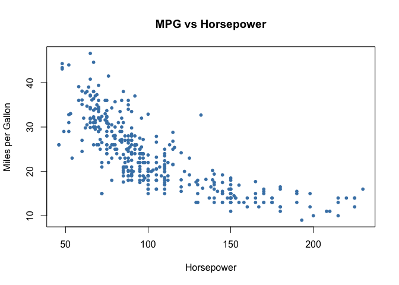

```r
data(auto_mpg)

# Remove missing horsepower values
auto_complete <- na.omit(auto_mpg[, c("mpg", "horsepower")])

# Visualize the relationship (clearly nonlinear)
plot(auto_complete$horsepower, auto_complete$mpg,
     main = "MPG vs Horsepower",
     xlab = "Horsepower", ylab = "Miles per Gallon",
     col = "steelblue", pch = 16, cex = 0.8)
```

### Fit Quadratic Model

```r
# Quadratic OLS
fit_auto_ols <- lm(mpg ~ horsepower + I(horsepower^2), data = auto_complete)

# Check residual properties
res_auto <- residuals(fit_auto_ols)
cat("Residual diagnostics:\n")
```

```
#> Residual diagnostics:
```

```r
cat("  Skewness (gamma3):", round(pmm_skewness(res_auto), 3), "\n")
```

```
#>   Skewness (gamma3): 0.218
```

```r
cat("  Excess kurtosis (gamma4):", round(pmm_kurtosis(res_auto), 3), "\n")
```

```
#>   Excess kurtosis (gamma4): 1.299
```

```r
sym_test <- test_symmetry(res_auto)
cat("  Symmetric:", sym_test$is_symmetric, "\n")
```

```
#>   Symmetric: TRUE
```

```r
# Dispatch recommendation
dispatch_auto <- pmm_dispatch(res_auto)
```

```
#> PMM method dispatch
#>   n = 392 | gamma3 = +0.218 | gamma4 = +1.299
#>   g2(PMM2) = 0.9856 | g3(PMM3) = 0.8951
#>   Selected: OLS (expected variance reduction: 0.0%)
#>   Reason: gamma3 = 0.218, gamma4 = 1.299: near-Gaussian residuals. No PMM advantage expected. Use OLS.
```

### Dispatcher Recommendation

```r
# Dispatcher-selected workflow: keep OLS, because gamma4 is positive.
cat("Dispatcher method:", dispatch_auto$method, "\n")
```

```
#> Dispatcher method: OLS
```

```r
cat("Reason:", dispatch_auto$reasoning, "\n")
```

```
#> Reason: gamma3 = 0.218, gamma4 = 1.299: near-Gaussian residuals. No PMM advantage expected. Use OLS.
```

This example is intentionally included as a guardrail: near-symmetry alone is not sufficient for PMM3. PMM3 is appropriate when the residuals are both near-symmetric and platykurtic (negative excess kurtosis).

### Visualize the OLS Fit

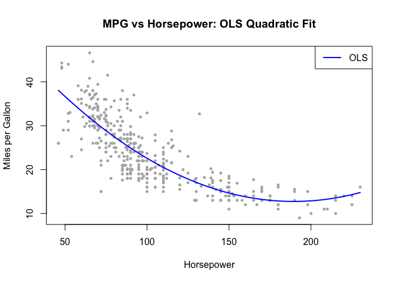

```r
hp_seq <- seq(min(auto_complete$horsepower),
              max(auto_complete$horsepower), length.out = 200)
newdata <- data.frame(horsepower = hp_seq)

pred_ols  <- predict(fit_auto_ols, newdata = newdata)

plot(auto_complete$horsepower, auto_complete$mpg,
     main = "MPG vs Horsepower: OLS Quadratic Fit",
     xlab = "Horsepower", ylab = "Miles per Gallon",
     col = "gray70", pch = 16, cex = 0.7)
lines(hp_seq, pred_ols, col = "blue", lwd = 2)
legend("topright", legend = "OLS", col = "blue", lty = 1, lwd = 2)
```

## Example 4: Real Data — Auto MPG (Linear, PMM2 Case)

For contrast, the regression of **MPG vs Acceleration** produces **asymmetric** residuals ($\gamma_3 \approx 0.5$), where PMM2 is appropriate instead.

```r
# Linear model: MPG vs Acceleration
fit_accel_ols <- lm(mpg ~ acceleration, data = auto_mpg)
res_accel <- residuals(fit_accel_ols)

cat("Acceleration residual diagnostics:\n")
```

```
#> Acceleration residual diagnostics:
```

```r
cat("  Skewness (gamma3):", round(pmm_skewness(res_accel), 3), "\n")
```

```
#>   Skewness (gamma3): 0.497
```

```r
cat("  Excess kurtosis (gamma4):", round(pmm_kurtosis(res_accel), 3), "\n")
```

```
#>   Excess kurtosis (gamma4): -0.33
```

```r
# Dispatch
dispatch_accel <- pmm_dispatch(res_accel)
```

```
#> PMM method dispatch
#>   n = 398 | gamma3 = +0.497 | gamma4 = -0.330
#>   g2(PMM2) = 0.8519 | g3(PMM3) = 0.9779
#>   Selected: PMM2 (expected variance reduction: 14.8%)
#>   Reason: |gamma3| = 0.497 > 0.3 and g2 = 0.852 < 0.95: moderate asymmetry, PMM2 worthwhile (14.8% reduction).
```

```r
# Compare
fit_accel_pmm2 <- lm_pmm2(mpg ~ acceleration, data = auto_mpg, na.action = na.omit)
vf2_accel <- pmm2_variance_factor(fit_accel_pmm2@m2, fit_accel_pmm2@m3, fit_accel_pmm2@m4)
cat("\nPMM2 g2 =", vf2_accel$g2,
    " (improvement:", round((1 - vf2_accel$g2) * 100, 1), "%)\n")
```

[output not shown]

This demonstrates how `pmm_dispatch()` guides users to the correct method: **PMM3 for symmetric platykurtic** residuals, **PMM2 for asymmetric** residuals.

## Example 5: Multiple Regression

PMM3 extends naturally to multiple predictors.

```r
n <- 300
x1 <- rnorm(n)
x2 <- runif(n, -2, 2)
x3 <- rnorm(n, 3, 1)

# True parameters
beta <- c(5, 1.5, -0.8, 2.0)

# Beta-symmetric errors (platykurtic, gamma4 ≈ -0.86)
errors_beta <- (rbeta(n, 3, 3) - 0.5) * sqrt(12 * 3)

y_multi <- beta[1] + beta[2]*x1 + beta[3]*x2 + beta[4]*x3 + errors_beta
dat_multi <- data.frame(y = y_multi, x1 = x1, x2 = x2, x3 = x3)

# Fit
fit_multi_ols  <- lm(y ~ x1 + x2 + x3, data = dat_multi)
fit_multi_pmm3 <- lm_pmm3(y ~ x1 + x2 + x3, data = dat_multi)

comparison_multi <- data.frame(
  Parameter = c("Intercept", "x1", "x2", "x3"),
  True  = beta,
  OLS   = coef(fit_multi_ols),
  PMM3  = coef(fit_multi_pmm3),
  Diff  = coef(fit_multi_pmm3) - coef(fit_multi_ols)
)
print(comparison_multi, row.names = FALSE, digits = 4)
```

```
#>  Parameter True     OLS    PMM3      Diff
#>  Intercept  5.0  4.9943  4.9668 -0.027433
#>         x1  1.5  1.6223  1.6114 -0.010928
#>         x2 -0.8 -0.7644 -0.7735 -0.009073
#>         x3  2.0  1.9923  1.9992  0.006979
```

```r
cat("\ng3 =", fit_multi_pmm3@g_coefficient,
    " (improvement:", round((1 - fit_multi_pmm3@g_coefficient) * 100, 1), "%)\n")
```

```
#>
#> g3 = 0.9000364  (improvement: 10 %)
```

## Example 6: No-Intercept Model

PMM3 supports models without an intercept term.

```r
# Model through the origin
y_noint <- 3 * x1 + errors_beta[1:n]
dat_noint <- data.frame(y = y_noint, x1 = x1)

fit_noint <- lm_pmm3(y ~ x1 - 1, data = dat_noint)
cat("True slope: 3\n")
```

```
#> True slope: 3
```

```r
cat("PMM3 estimate:", coef(fit_noint), "\n")
```

```
#> PMM3 estimate: 3.11516
```

```r
cat("Converged:", fit_noint@convergence, "\n")
```

```
#> Converged: TRUE
```

## Interpreting the PMM3 Summary

The `summary()` method reports several PMM3-specific quantities:

```r
summary(fit_pmm3)
```

```
#> PMM3 estimation results (S = 3, symmetric errors)
#> Call:
#> lm_pmm3(formula = y ~ x, data = dat)
#>
#> Coefficients:
#> (Intercept)           x
#>    9.916678    2.518456
#>
#> Central moments of initial residuals:
#>   m2 = 0.9555941
#>   m4 = 1.658808
#>   m6 = 3.424153
#>
#> Theoretical characteristics of PMM3 (S = 3):
#>   gamma4 = -1.183442
#>   gamma6 = 6.675667
#>   g3     = 0.3082707  (expected ratio Var[PMM3]/Var[OLS])
#>   kappa  = 1.231908
#>
#> Algorithm information:
#>   Convergence status: TRUE
#>   Iterations: 3
```

[output not shown]

**Rule of thumb:** If $g_3 < 0.90$, PMM3 provides a meaningful improvement over OLS ($> 10\%$ variance reduction).

## Adaptive Mode

By default, PMM3 computes $\kappa$ from OLS residuals and holds it fixed throughout the Newton-Raphson iterations. In **adaptive mode**, $\kappa$ is re-estimated from the current residuals at each iteration:

```r
fit_fixed    <- lm_pmm3(y ~ x, data = dat, adaptive = FALSE)
fit_adaptive <- lm_pmm3(y ~ x, data = dat, adaptive = TRUE)

comparison_adapt <- data.frame(
  Mode       = c("Fixed kappa", "Adaptive kappa"),
  Intercept  = c(coef(fit_fixed)[1], coef(fit_adaptive)[1]),
  Slope      = c(coef(fit_fixed)[2], coef(fit_adaptive)[2]),
  Iterations = c(fit_fixed@iterations, fit_adaptive@iterations)
)
print(comparison_adapt, row.names = FALSE, digits = 5)
```

```
#>            Mode Intercept  Slope Iterations
#>     Fixed kappa    9.9167 2.5185          3
#>  Adaptive kappa    9.9177 2.5183          4
```

Adaptive mode can improve estimates when the error distribution departs significantly from what the initial OLS residuals suggest, at the cost of additional iterations.

## Diagnostic Plots

PMM3 provides four diagnostic plots:

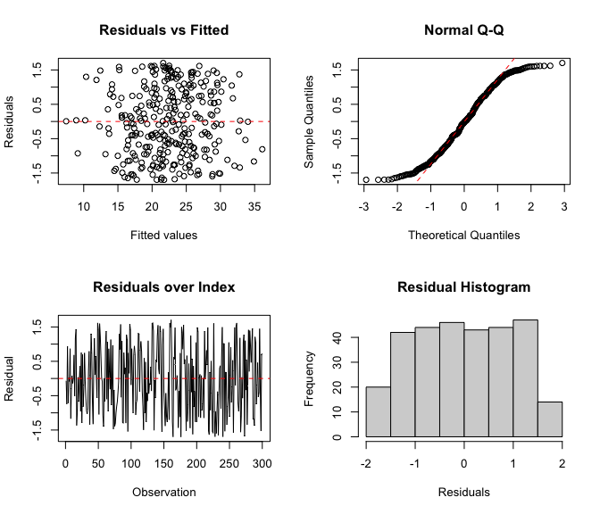

```r
plot(fit_pmm3)
```

## Utility Functions

### Automatic Method Selection

```r
# Symmetric platykurtic errors → PMM3
pmm_dispatch(runif(500, -1, 1))
```

```
#> PMM method dispatch
#>   n = 500 | gamma3 = -0.026 | gamma4 = -1.272
#>   g2(PMM2) = 0.9990 | g3(PMM3) = 0.2438
#>   Selected: PMM3 (expected variance reduction: 75.6%)
#>   Reason: |gamma3| = 0.026 < 0.3 (symmetric) and gamma4 = -1.272 < -0.7 (platykurtic). PMM3 expected to reduce variance by 75.6%.
```

```r
# Asymmetric errors → PMM2
pmm_dispatch(rexp(500) - 1)
```

```
#> PMM method dispatch
#>   n = 500 | gamma3 = +2.351 | gamma4 = +8.946
#>   g2(PMM2) = 0.4953 | g3(PMM3) = 0.7901
#>   Selected: PMM2 (expected variance reduction: 50.5%)
#>   Reason: |gamma3| = 2.351 > 1.0: strong asymmetry detected. PMM2 expected to reduce variance by 50.5%.
```

```r
# Gaussian errors → OLS
pmm_dispatch(rnorm(500))
```

```
#> PMM method dispatch
#>   n = 500 | gamma3 = -0.001 | gamma4 = +0.007
#>   g2(PMM2) = 1.0000 | g3(PMM3) = 1.0000
#>   Selected: OLS (expected variance reduction: 0.0%)
#>   Reason: gamma3 = -0.001, gamma4 = 0.007: near-Gaussian residuals. No PMM advantage expected. Use OLS.
```

### Testing Symmetry

```r
test_symmetry(residuals(fit_ols))
```

```
#> $gamma3
#> [1] 0.02563207
#>
#> $is_symmetric
#> [1] TRUE
#>
#> $message
#> [1] "|gamma3| = 0.026 <= 0.3: residuals are symmetric. PMM3 may be appropriate."
```

### Computing Moments

```r
mom <- compute_moments_pmm3(residuals(fit_ols))
cat("m2 =", mom$m2, "\n")
```

```
#> m2 = 0.9555941
```

```r
cat("m4 =", mom$m4, "\n")
```

```
#> m4 = 1.658808
```

```r
cat("m6 =", mom$m6, "\n")
```

```
#> m6 = 3.424153
```

```r
cat("gamma4 =", mom$gamma4, "\n")
```

```
#> gamma4 = -1.183442
```

```r
cat("kappa =", mom$kappa, "\n")
```

```
#> kappa = 1.231908
```

```r
cat("g3 =", mom$g3, "\n")
```

```
#> g3 = 0.3082707
```

### Sixth-Order Cumulant

```r
pmm_gamma6(residuals(fit_ols))
```

```
#> [1] 6.675667
```

### Variance Factor

```r
pmm3_variance_factor(mom$m2, mom$m4, mom$m6)
```

```
#> $gamma4
#> [1] -1.183442
#>
#> $gamma6
#> [1] 6.675667
#>
#> $g3
#> [1] 0.3082707
```

## When to Use PMM3

**Use PMM3 when:**

- Residuals are **symmetric** ($|\gamma_3| \leq 0.3$)
- Residuals are **platykurtic** ($\gamma_4 < -0.7$)
- Error distributions are bounded (uniform, beta-symmetric, truncated normal)
- Sample size is **moderate to large** ($n \geq 100$, ideally $n \geq 200$)

**Use PMM2 instead when:**

- Residuals are **skewed** ($|\gamma_3| > 0.3$)

**Stick with OLS when:**

- Residuals are approximately **Gaussian** ($|\gamma_4| < 0.7$, $|\gamma_3| < 0.3$)
- Very small samples ($n < 50$)

### Decision Workflow

1. **Fit OLS** as baseline
2. **Check residuals**: `pmm_skewness()`, `pmm_kurtosis()`, `test_symmetry()`
3. **Use `pmm_dispatch()`** for automatic recommendation
4. **Refit** with the recommended method
5. **Compare** coefficients and efficiency factors

## Efficiency Summary (Monte Carlo Evidence)

Based on Monte Carlo simulations (R = 1000 replications):

[output not shown]

**Key insight:** The more platykurtic the errors ($\gamma_4$ further from 0), the larger the efficiency gain from PMM3.

## Next Steps

- **PMM3 Time Series**: See `vignette("pmm3_time_series")` for AR, MA, ARMA, ARIMA models with PMM3
- **PMM2 Introduction**: See `vignette("pmm2_introduction")` for asymmetric error estimation
- **PMM2 Time Series**: See `vignette("pmm2_time_series")` for PMM2 time series models
- **Bootstrap Inference**: See `vignette("bootstrap_inference")`

## References

1. Zabolotnii S., Warsza Z.L., Tkachenko O. (2018). Polynomial Estimation of Linear Regression Parameters for the Asymmetric PDF of Errors. Springer AISC, vol 743. doi:10.1007/978-3-319-77179-3_75
2. Package functions: `?lm_pmm3`, `?pmm_dispatch`, `?compute_moments_pmm3`, `?test_symmetry`, `?pmm_gamma6`
3. GitHub: https://github.com/SZabolotnii/EstemPMM